# Risk Factor Analysis

## Outcome Variable

**Outcome Variable:** ever_wasted

## Predictor Variables

**Intervention Variable:** exclfeed36

**Adjustment Set:**

- arm
- sex
- brthmon
- W_mage
- meducyrs
- feducyrs
- hhwealth_quart
- hfoodsec
- W_mhtcm
- W_mwtkg
- W_mbmi
- vagbrth
- W_gagebrth
- W_birthwt
- W_birthlen
- W_nrooms
- W_nchldlt5
- month
- W_parity
- impfloor
- impsan
- safeh20
- delta_W_mage
- delta_meducyrs
- delta_feducyrs
- delta_hhwealth_quart
- delta_hfoodsec
- delta_W_mhtcm
- delta_W_mwtkg
- delta_W_mbmi
- delta_vagbrth
- delta_W_gagebrth
- delta_W_birthwt
- delta_W_birthlen
- delta_W_nrooms
- delta_W_nchldlt5
- delta_month
- delta_W_parity
- delta_impfloor
- delta_impsan
- delta_safeh20

## Stratifying Variables

The analysis was stratified on these variable(s):

- agecat
- studyid
- country

## Data Summary

| agecat | studyid | country | exclfeed36 | ever_wasted | n_cell | n |
| --- | --- | --- | --- | --- | --- | --- |
| 0-24 months (no birth wast) | CMC-V-BCS-2002 | INDIA | 1 | 0 | 7 | 9 |
| 0-24 months (no birth wast) | CMC-V-BCS-2002 | INDIA | 1 | 1 | 2 | 9 |
| 0-24 months (no birth wast) | CMC-V-BCS-2002 | INDIA | 0 | 0 | 0 | 9 |
| 0-24 months (no birth wast) | CMC-V-BCS-2002 | INDIA | 0 | 1 | 0 | 9 |
| 0-24 months (no birth wast) | EE | PAKISTAN | 1 | 0 | 3 | 9 |
| 0-24 months (no birth wast) | EE | PAKISTAN | 1 | 1 | 1 | 9 |
| 0-24 months (no birth wast) | EE | PAKISTAN | 0 | 0 | 3 | 9 |
| 0-24 months (no birth wast) | EE | PAKISTAN | 0 | 1 | 2 | 9 |
| 0-24 months (no birth wast) | GMS-Nepal | NEPAL | 1 | 0 | 180 | 524 |
| 0-24 months (no birth wast) | GMS-Nepal | NEPAL | 1 | 1 | 240 | 524 |
| 0-24 months (no birth wast) | GMS-Nepal | NEPAL | 0 | 0 | 47 | 524 |
| 0-24 months (no birth wast) | GMS-Nepal | NEPAL | 0 | 1 | 57 | 524 |
| 0-24 months (no birth wast) | IRC | INDIA | 1 | 0 | 0 | 4 |
| 0-24 months (no birth wast) | IRC | INDIA | 1 | 1 | 0 | 4 |
| 0-24 months (no birth wast) | IRC | INDIA | 0 | 0 | 1 | 4 |
| 0-24 months (no birth wast) | IRC | INDIA | 0 | 1 | 3 | 4 |
| 0-24 months (no birth wast) | JiVitA-3 | BANGLADESH | 1 | 0 | 8049 | 12568 |
| 0-24 months (no birth wast) | JiVitA-3 | BANGLADESH | 1 | 1 | 1725 | 12568 |
| 0-24 months (no birth wast) | JiVitA-3 | BANGLADESH | 0 | 0 | 2263 | 12568 |
| 0-24 months (no birth wast) | JiVitA-3 | BANGLADESH | 0 | 1 | 531 | 12568 |
| 0-24 months (no birth wast) | JiVitA-4 | BANGLADESH | 1 | 0 | 2634 | 4559 |
| 0-24 months (no birth wast) | JiVitA-4 | BANGLADESH | 1 | 1 | 886 | 4559 |
| 0-24 months (no birth wast) | JiVitA-4 | BANGLADESH | 0 | 0 | 734 | 4559 |
| 0-24 months (no birth wast) | JiVitA-4 | BANGLADESH | 0 | 1 | 305 | 4559 |
| 0-24 months (no birth wast) | Keneba | GAMBIA | 1 | 0 | 405 | 1974 |
| 0-24 months (no birth wast) | Keneba | GAMBIA | 1 | 1 | 218 | 1974 |
| 0-24 months (no birth wast) | Keneba | GAMBIA | 0 | 0 | 789 | 1974 |
| 0-24 months (no birth wast) | Keneba | GAMBIA | 0 | 1 | 562 | 1974 |
| 0-24 months (no birth wast) | LCNI-5 | MALAWI | 1 | 0 | 42 | 271 |
| 0-24 months (no birth wast) | LCNI-5 | MALAWI | 1 | 1 | 5 | 271 |

[output cut: 106 more lines]

The following strata were considered:

- agecat: 0-24 months (no birth wast), studyid: CMC-V-BCS-2002, country: INDIA
- agecat: 0-24 months (no birth wast), studyid: EE, country: PAKISTAN
- agecat: 0-24 months (no birth wast), studyid: GMS-Nepal, country: NEPAL
- agecat: 0-24 months (no birth wast), studyid: IRC, country: INDIA
- agecat: 0-24 months (no birth wast), studyid: JiVitA-3, country: BANGLADESH
- agecat: 0-24 months (no birth wast), studyid: JiVitA-4, country: BANGLADESH
- agecat: 0-24 months (no birth wast), studyid: Keneba, country: GAMBIA
- agecat: 0-24 months (no birth wast), studyid: LCNI-5, country: MALAWI
- agecat: 0-24 months (no birth wast), studyid: MAL-ED, country: BANGLADESH
- agecat: 0-24 months (no birth wast), studyid: MAL-ED, country: BRAZIL
- agecat: 0-24 months (no birth wast), studyid: MAL-ED, country: INDIA
- agecat: 0-24 months (no birth wast), studyid: MAL-ED, country: NEPAL
- agecat: 0-24 months (no birth wast), studyid: MAL-ED, country: PERU
- agecat: 0-24 months (no birth wast), studyid: MAL-ED, country: SOUTH AFRICA
- agecat: 0-24 months (no birth wast), studyid: MAL-ED, country: TANZANIA, UNITED REPUBLIC OF
- agecat: 0-24 months (no birth wast), studyid: PROVIDE, country: BANGLADESH
- agecat: 0-24 months (no birth wast), studyid: SAS-FoodSuppl, country: INDIA
- agecat: 0-6 months (no birth wast), studyid: CMC-V-BCS-2002, country: INDIA
- agecat: 0-6 months (no birth wast), studyid: EE, country: PAKISTAN
- agecat: 0-6 months (no birth wast), studyid: GMS-Nepal, country: NEPAL
- agecat: 0-6 months (no birth wast), studyid: IRC, country: INDIA
- agecat: 0-6 months (no birth wast), studyid: JiVitA-3, country: BANGLADESH
- agecat: 0-6 months (no birth wast), studyid: JiVitA-4, country: BANGLADESH
- agecat: 0-6 months (no birth wast), studyid: Keneba, country: GAMBIA
- agecat: 0-6 months (no birth wast), studyid: LCNI-5, country: MALAWI
- agecat: 0-6 months (no birth wast), studyid: MAL-ED, country: BANGLADESH
- agecat: 0-6 months (no birth wast), studyid: MAL-ED, country: BRAZIL
- agecat: 0-6 months (no birth wast), studyid: MAL-ED, country: INDIA
- agecat: 0-6 months (no birth wast), studyid: MAL-ED, country: NEPAL
- agecat: 0-6 months (no birth wast), studyid: MAL-ED, country: PERU
- agecat: 0-6 months (no birth wast), studyid: MAL-ED, country: SOUTH AFRICA
- agecat: 0-6 months (no birth wast), studyid: MAL-ED, country: TANZANIA, UNITED REPUBLIC OF
- agecat: 0-6 months (no birth wast), studyid: PROVIDE, country: BANGLADESH
- agecat: 0-6 months (no birth wast), studyid: SAS-FoodSuppl, country: INDIA

### Dropped Strata

Some strata were dropped due to rare outcomes:

- agecat: 0-24 months (no birth wast), studyid: CMC-V-BCS-2002, country: INDIA
- agecat: 0-24 months (no birth wast), studyid: EE, country: PAKISTAN
- agecat: 0-24 months (no birth wast), studyid: IRC, country: INDIA
- agecat: 0-24 months (no birth wast), studyid: MAL-ED, country: BRAZIL
- agecat: 0-24 months (no birth wast), studyid: MAL-ED, country: NEPAL
- agecat: 0-24 months (no birth wast), studyid: MAL-ED, country: PERU
- agecat: 0-24 months (no birth wast), studyid: MAL-ED, country: SOUTH AFRICA
- agecat: 0-24 months (no birth wast), studyid: MAL-ED, country: TANZANIA, UNITED REPUBLIC OF
- agecat: 0-24 months (no birth wast), studyid: SAS-FoodSuppl, country: INDIA
- agecat: 0-6 months (no birth wast), studyid: CMC-V-BCS-2002, country: INDIA
- agecat: 0-6 months (no birth wast), studyid: EE, country: PAKISTAN
- agecat: 0-6 months (no birth wast), studyid: IRC, country: INDIA
- agecat: 0-6 months (no birth wast), studyid: LCNI-5, country: MALAWI
- agecat: 0-6 months (no birth wast), studyid: MAL-ED, country: BANGLADESH
- agecat: 0-6 months (no birth wast), studyid: MAL-ED, country: BRAZIL
- agecat: 0-6 months (no birth wast), studyid: MAL-ED, country: INDIA
- agecat: 0-6 months (no birth wast), studyid: MAL-ED, country: NEPAL
- agecat: 0-6 months (no birth wast), studyid: MAL-ED, country: PERU
- agecat: 0-6 months (no birth wast), studyid: MAL-ED, country: SOUTH AFRICA
- agecat: 0-6 months (no birth wast), studyid: MAL-ED, country: TANZANIA, UNITED REPUBLIC OF
- agecat: 0-6 months (no birth wast), studyid: SAS-FoodSuppl, country: INDIA

## Methods Detail

We're interested in the causal parameters $E[Y_a]$ for all values of $a \in \mathcal{A}$. These parameters represent the mean outcome if, possibly contrary to fact, we intervened to set all units to have $A=a$. Under the randomization and positivity assumptions, these are identified by the statistical parameters $\psi_a=E_W[E_{Y|A,W}(Y|A=a,W)]$. In addition, we're interested in the mean of $Y$, $E[Y]$ under no intervention (the observed mean). We will estimate these parameters by using SuperLearner to fit the relevant likelihood factors -- $E_{Y|A,W}(Y|A=a,W)$ and $p(A=a|W)$, and then updating our likelihood fit using a joint TMLE.

For unadjusted analyses ($W=\{\}$), initial likelihoods were estimated using Lrnr_glm to estimate the simple $E(Y|A)$ and Lrnr_mean to estimate $p(A)$. For adjusted analyses, a small library containing Lrnr_glmnet, Lrnr_xgboost, and Lrnr_mean was used.

Having estimated these parameters, we will then use the delta method to estimate relative risks and attributable risks relative to a prespecified baseline level of $A$.

# Results Detail

## Results Plots

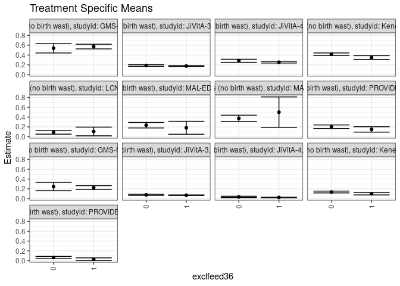

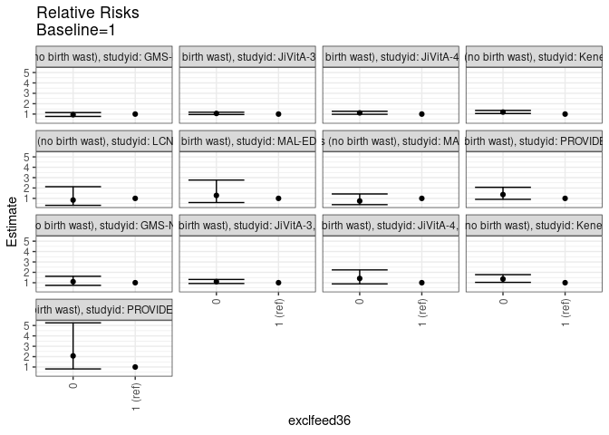

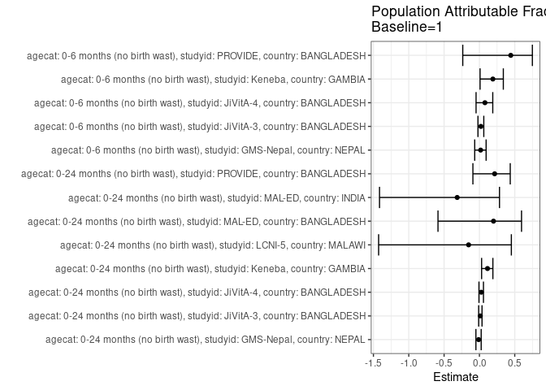

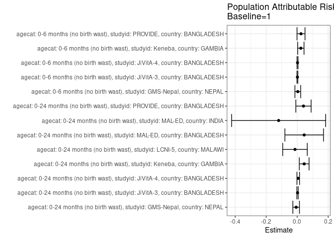

## Results Table

### Parameter: TSM

| agecat | studyid | country | intervention_level | baseline_level | estimate | ci_lower | ci_upper |
| --- | --- | --- | --- | --- | --- | --- | --- |
| 0-24 months (no birth wast) | GMS-Nepal | NEPAL | 1 | NA | 0.5734228 | 0.5260298 | 0.6208157 |
| 0-24 months (no birth wast) | GMS-Nepal | NEPAL | 0 | NA | 0.5396604 | 0.4428894 | 0.6364315 |
| 0-24 months (no birth wast) | JiVitA-3 | BANGLADESH | 1 | NA | 0.1770857 | 0.1686687 | 0.1855027 |
| 0-24 months (no birth wast) | JiVitA-3 | BANGLADESH | 0 | NA | 0.1880671 | 0.1710128 | 0.2051215 |
| 0-24 months (no birth wast) | JiVitA-4 | BANGLADESH | 1 | NA | 0.2544882 | 0.2371336 | 0.2718428 |
| 0-24 months (no birth wast) | JiVitA-4 | BANGLADESH | 0 | NA | 0.2836247 | 0.2521149 | 0.3151346 |
| 0-24 months (no birth wast) | Keneba | GAMBIA | 1 | NA | 0.3499539 | 0.3122817 | 0.3876261 |
| 0-24 months (no birth wast) | Keneba | GAMBIA | 0 | NA | 0.4171163 | 0.3909718 | 0.4432607 |
| 0-24 months (no birth wast) | LCNI-5 | MALAWI | 1 | NA | 0.1063830 | 0.0180722 | 0.1946938 |
| 0-24 months (no birth wast) | LCNI-5 | MALAWI | 0 | NA | 0.0892857 | 0.0518739 | 0.1266975 |
| 0-24 months (no birth wast) | MAL-ED | BANGLADESH | 1 | NA | 0.1818182 | 0.0499617 | 0.3136747 |
| 0-24 months (no birth wast) | MAL-ED | BANGLADESH | 0 | NA | 0.2339450 | 0.1776365 | 0.2902534 |
| 0-24 months (no birth wast) | MAL-ED | INDIA | 1 | NA | 0.5000000 | 0.1894382 | 0.8105618 |
| 0-24 months (no birth wast) | MAL-ED | INDIA | 0 | NA | 0.3750000 | 0.3114655 | 0.4385345 |
| 0-24 months (no birth wast) | PROVIDE | BANGLADESH | 1 | NA | 0.1482973 | 0.0931769 | 0.2034177 |
| 0-24 months (no birth wast) | PROVIDE | BANGLADESH | 0 | NA | 0.2029982 | 0.1666824 | 0.2393141 |
| 0-6 months (no birth wast) | GMS-Nepal | NEPAL | 1 | NA | 0.2254126 | 0.1848559 | 0.2659692 |
| 0-6 months (no birth wast) | GMS-Nepal | NEPAL | 0 | NA | 0.2476717 | 0.1625845 | 0.3327588 |
| 0-6 months (no birth wast) | JiVitA-3 | BANGLADESH | 1 | NA | 0.0703836 | 0.0646683 | 0.0760988 |
| 0-6 months (no birth wast) | JiVitA-3 | BANGLADESH | 0 | NA | 0.0775072 | 0.0652848 | 0.0897295 |
| 0-6 months (no birth wast) | JiVitA-4 | BANGLADESH | 1 | NA | 0.0253691 | 0.0190793 | 0.0316590 |
| 0-6 months (no birth wast) | JiVitA-4 | BANGLADESH | 0 | NA | 0.0357498 | 0.0223739 | 0.0491256 |
| 0-6 months (no birth wast) | Keneba | GAMBIA | 1 | NA | 0.1003805 | 0.0768033 | 0.1239576 |
| 0-6 months (no birth wast) | Keneba | GAMBIA | 0 | NA | 0.1359444 | 0.1176571 | 0.1542318 |
| 0-6 months (no birth wast) | PROVIDE | BANGLADESH | 1 | NA | 0.0308642 | 0.0042107 | 0.0575177 |
| 0-6 months (no birth wast) | PROVIDE | BANGLADESH | 0 | NA | 0.0639659 | 0.0418030 | 0.0861288 |

### Parameter: E(Y)

| agecat | studyid | country | intervention_level | baseline_level | estimate | ci_lower | ci_upper |
| --- | --- | --- | --- | --- | --- | --- | --- |
| 0-24 months (no birth wast) | GMS-Nepal | NEPAL | NA | NA | 0.5667939 | 0.5243264 | 0.6092614 |
| 0-24 months (no birth wast) | JiVitA-3 | BANGLADESH | NA | NA | 0.1795035 | 0.1720409 | 0.1869661 |
| 0-24 months (no birth wast) | JiVitA-4 | BANGLADESH | NA | NA | 0.2612415 | 0.2461119 | 0.2763711 |
| 0-24 months (no birth wast) | Keneba | GAMBIA | NA | NA | 0.3951368 | 0.3735650 | 0.4167086 |
| 0-24 months (no birth wast) | LCNI-5 | MALAWI | NA | NA | 0.0922509 | 0.0577338 | 0.1267680 |
| 0-24 months (no birth wast) | MAL-ED | BANGLADESH | NA | NA | 0.2270916 | 0.1751587 | 0.2790245 |
| 0-24 months (no birth wast) | MAL-ED | INDIA | NA | NA | 0.3803419 | 0.3180067 | 0.4426771 |
| 0-24 months (no birth wast) | PROVIDE | BANGLADESH | NA | NA | 0.1889764 | 0.1585028 | 0.2194500 |
| 0-6 months (no birth wast) | GMS-Nepal | NEPAL | NA | NA | 0.2294118 | 0.1928853 | 0.2659383 |
| 0-6 months (no birth wast) | JiVitA-3 | BANGLADESH | NA | NA | 0.0719217 | 0.0666549 | 0.0771884 |
| 0-6 months (no birth wast) | JiVitA-4 | BANGLADESH | NA | NA | 0.0275209 | 0.0219532 | 0.0330885 |
| 0-6 months (no birth wast) | Keneba | GAMBIA | NA | NA | 0.1239796 | 0.1093860 | 0.1385732 |
| 0-6 months (no birth wast) | PROVIDE | BANGLADESH | NA | NA | 0.0554675 | 0.0375942 | 0.0733408 |

### Parameter: RR

| agecat | studyid | country | intervention_level | baseline_level | estimate | ci_lower | ci_upper |
| --- | --- | --- | --- | --- | --- | --- | --- |
| 0-24 months (no birth wast) | GMS-Nepal | NEPAL | 1 | 1 | 1.0000000 | 1.0000000 | 1.000000 |
| 0-24 months (no birth wast) | GMS-Nepal | NEPAL | 0 | 1 | 0.9411213 | 0.7725818 | 1.146428 |
| 0-24 months (no birth wast) | JiVitA-3 | BANGLADESH | 1 | 1 | 1.0000000 | 1.0000000 | 1.000000 |
| 0-24 months (no birth wast) | JiVitA-3 | BANGLADESH | 0 | 1 | 1.0620120 | 0.9575110 | 1.177918 |
| 0-24 months (no birth wast) | JiVitA-4 | BANGLADESH | 1 | 1 | 1.0000000 | 1.0000000 | 1.000000 |
| 0-24 months (no birth wast) | JiVitA-4 | BANGLADESH | 0 | 1 | 1.1144906 | 0.9801142 | 1.267291 |
| 0-24 months (no birth wast) | Keneba | GAMBIA | 1 | 1 | 1.0000000 | 1.0000000 | 1.000000 |
| 0-24 months (no birth wast) | Keneba | GAMBIA | 0 | 1 | 1.1919178 | 1.0527002 | 1.349547 |
| 0-24 months (no birth wast) | LCNI-5 | MALAWI | 1 | 1 | 1.0000000 | 1.0000000 | 1.000000 |
| 0-24 months (no birth wast) | LCNI-5 | MALAWI | 0 | 1 | 0.8392857 | 0.3311837 | 2.126918 |
| 0-24 months (no birth wast) | MAL-ED | BANGLADESH | 1 | 1 | 1.0000000 | 1.0000000 | 1.000000 |
| 0-24 months (no birth wast) | MAL-ED | BANGLADESH | 0 | 1 | 1.2866972 | 0.5992775 | 2.762643 |
| 0-24 months (no birth wast) | MAL-ED | INDIA | 1 | 1 | 1.0000000 | 1.0000000 | 1.000000 |
| 0-24 months (no birth wast) | MAL-ED | INDIA | 0 | 1 | 0.7500000 | 0.3939629 | 1.427799 |
| 0-24 months (no birth wast) | PROVIDE | BANGLADESH | 1 | 1 | 1.0000000 | 1.0000000 | 1.000000 |
| 0-24 months (no birth wast) | PROVIDE | BANGLADESH | 0 | 1 | 1.3688594 | 0.9060918 | 2.067976 |
| 0-6 months (no birth wast) | GMS-Nepal | NEPAL | 1 | 1 | 1.0000000 | 1.0000000 | 1.000000 |
| 0-6 months (no birth wast) | GMS-Nepal | NEPAL | 0 | 1 | 1.0987483 | 0.7458607 | 1.618597 |
| 0-6 months (no birth wast) | JiVitA-3 | BANGLADESH | 1 | 1 | 1.0000000 | 1.0000000 | 1.000000 |
| 0-6 months (no birth wast) | JiVitA-3 | BANGLADESH | 0 | 1 | 1.1012113 | 0.9235825 | 1.313003 |
| 0-6 months (no birth wast) | JiVitA-4 | BANGLADESH | 1 | 1 | 1.0000000 | 1.0000000 | 1.000000 |
| 0-6 months (no birth wast) | JiVitA-4 | BANGLADESH | 0 | 1 | 1.4091824 | 0.8891316 | 2.233410 |
| 0-6 months (no birth wast) | Keneba | GAMBIA | 1 | 1 | 1.0000000 | 1.0000000 | 1.000000 |
| 0-6 months (no birth wast) | Keneba | GAMBIA | 0 | 1 | 1.3542920 | 1.0333385 | 1.774933 |
| 0-6 months (no birth wast) | PROVIDE | BANGLADESH | 1 | 1 | 1.0000000 | 1.0000000 | 1.000000 |
| 0-6 months (no birth wast) | PROVIDE | BANGLADESH | 0 | 1 | 2.0724947 | 0.8173110 | 5.255324 |

### Parameter: PAR

| agecat | studyid | country | intervention_level | baseline_level | estimate | ci_lower | ci_upper |
| --- | --- | --- | --- | --- | --- | --- | --- |
| 0-24 months (no birth wast) | GMS-Nepal | NEPAL | 1 | NA | -0.0066289 | -0.0278617 | 0.0146039 |
| 0-24 months (no birth wast) | JiVitA-3 | BANGLADESH | 1 | NA | 0.0024178 | -0.0018579 | 0.0066935 |
| 0-24 months (no birth wast) | JiVitA-4 | BANGLADESH | 1 | NA | 0.0067533 | -0.0015354 | 0.0150419 |
| 0-24 months (no birth wast) | Keneba | GAMBIA | 1 | NA | 0.0451829 | 0.0137533 | 0.0766125 |
| 0-24 months (no birth wast) | LCNI-5 | MALAWI | 1 | NA | -0.0141321 | -0.0934107 | 0.0651466 |
| 0-24 months (no birth wast) | MAL-ED | BANGLADESH | 1 | NA | 0.0452735 | -0.0792718 | 0.1698187 |
| 0-24 months (no birth wast) | MAL-ED | INDIA | 1 | NA | -0.1196581 | -0.4231229 | 0.1838066 |
| 0-24 months (no birth wast) | PROVIDE | BANGLADESH | 1 | NA | 0.0406790 | -0.0086101 | 0.0899682 |
| 0-6 months (no birth wast) | GMS-Nepal | NEPAL | 1 | NA | 0.0039992 | -0.0145115 | 0.0225099 |
| 0-6 months (no birth wast) | JiVitA-3 | BANGLADESH | 1 | NA | 0.0015381 | -0.0014425 | 0.0045187 |
| 0-6 months (no birth wast) | JiVitA-4 | BANGLADESH | 1 | NA | 0.0021517 | -0.0010853 | 0.0053887 |
| 0-6 months (no birth wast) | Keneba | GAMBIA | 1 | NA | 0.0235991 | 0.0031732 | 0.0440251 |
| 0-6 months (no birth wast) | PROVIDE | BANGLADESH | 1 | NA | 0.0246033 | -0.0011861 | 0.0503927 |

### Parameter: PAF

| agecat | studyid | country | intervention_level | baseline_level | estimate | ci_lower | ci_upper |
| --- | --- | --- | --- | --- | --- | --- | --- |
| 0-24 months (no birth wast) | GMS-Nepal | NEPAL | 1 | NA | -0.0116954 | -0.0498736 | 0.0250945 |
| 0-24 months (no birth wast) | JiVitA-3 | BANGLADESH | 1 | NA | 0.0134693 | -0.0106190 | 0.0369835 |
| 0-24 months (no birth wast) | JiVitA-4 | BANGLADESH | 1 | NA | 0.0258507 | -0.0064580 | 0.0571223 |
| 0-24 months (no birth wast) | Keneba | GAMBIA | 1 | NA | 0.1143475 | 0.0310284 | 0.1905022 |
| 0-24 months (no birth wast) | LCNI-5 | MALAWI | 1 | NA | -0.1531915 | -1.4265796 | 0.4519650 |
| 0-24 months (no birth wast) | MAL-ED | BANGLADESH | 1 | NA | 0.1993620 | -0.5862897 | 0.5958991 |
| 0-24 months (no birth wast) | MAL-ED | INDIA | 1 | NA | -0.3146067 | -1.4139018 | 0.2840674 |
| 0-24 months (no birth wast) | PROVIDE | BANGLADESH | 1 | NA | 0.2152599 | -0.0922001 | 0.4361683 |
| 0-6 months (no birth wast) | GMS-Nepal | NEPAL | 1 | NA | 0.0174324 | -0.0666413 | 0.0948793 |
| 0-6 months (no birth wast) | JiVitA-3 | BANGLADESH | 1 | NA | 0.0213859 | -0.0207707 | 0.0618014 |
| 0-6 months (no birth wast) | JiVitA-4 | BANGLADESH | 1 | NA | 0.0781850 | -0.0475208 | 0.1888058 |
| 0-6 months (no birth wast) | Keneba | GAMBIA | 1 | NA | 0.1903469 | 0.0091955 | 0.3383780 |
| 0-6 months (no birth wast) | PROVIDE | BANGLADESH | 1 | NA | 0.4435626 | -0.2356792 | 0.7494313 |